# Homework 5

Marko Danchak

2026-01-22

## Instructions

Answer the following questions and/or complete the exercises in RMarkdown. Please embed all of your code and push the final work to your repository. Your report should be organized, clean, and run free from errors. Remember, you must remove the `#` for any included code chunks to run. Any plots must have appropriate titles and aesthetics.

## Load the tidyverse

```r
library("tidyverse")
options(scipen=999) #turn off scientific notation
```

## Data

**Database of vertebrate home range sizes.** Reference: Tamburello N, Cote IM, Dulvy NK (2015) Energy and the scaling of animal space use. The American Naturalist 186(2):196-211. http://dx.doi.org/10.1086/682070.  
Data: http://datadryad.org/resource/doi:10.5061/dryad.q5j65/1

**1. Load the data into a new object called `homerange`.**

```r
getwd()
```

```
## [1] "/Users/markodanchak/Downloads/BIS15L_W26_jmledford-main 2/lab5"
```

```r
setwd("/Users/markodanchak/Desktop")
homerange <-  read_csv("Tamburelloetal_HomeRangeDatabase.csv")
```

**2. What is the structure of the `homerange` data? Does it have any NA’s? Do a quick exploratory analysis of your choice below.**

```r
glimpse(homerange)
```

```
## Rows: 569
## Columns: 24
## $ taxon                      <chr> "lake fishes", "river fishes", "river fishe…
## $ common.name                <chr> "american eel", "blacktail redhorse", "cent…
## $ class                      <chr> "actinopterygii", "actinopterygii", "actino…
## $ order                      <chr> "anguilliformes", "cypriniformes", "cyprini…
## $ family                     <chr> "anguillidae", "catostomidae", "cyprinidae"…
## $ genus                      <chr> "anguilla", "moxostoma", "campostoma", "cli…
## $ species                    <chr> "rostrata", "poecilura", "anomalum", "fundu…
## $ primarymethod              <chr> "telemetry", "mark-recapture", "mark-recapt…
## $ N                          <chr> "16", NA, "20", "26", "17", "5", "2", "2", …
## $ mean.mass.g                <dbl> 887.00, 562.00, 34.00, 4.00, 4.00, 3525.00,…
## $ log10.mass                 <dbl> 2.9479236, 2.7497363, 1.5314789, 0.6020600,…
## $ alternative.mass.reference <chr> NA, NA, NA, NA, NA, NA, NA, NA, NA, NA, NA,…
## $ mean.hra.m2                <dbl> 282750.00, 282.10, 116.11, 125.50, 87.10, 3…
## $ log10.hra                  <dbl> 5.4514026, 2.4504031, 2.0648696, 2.0986437,…
## $ hra.reference              <chr> "Minns, C. K. 1995. Allometry of home range…
## $ realm                      <chr> "aquatic", "aquatic", "aquatic", "aquatic",…
## $ thermoregulation           <chr> "ectotherm", "ectotherm", "ectotherm", "ect…
## $ locomotion                 <chr> "swimming", "swimming", "swimming", "swimmi…
## $ trophic.guild              <chr> "carnivore", "carnivore", "carnivore", "car…
## $ dimension                  <dbl> 3, 2, 2, 2, 2, 2, 2, 2, 2, 2, 2, 2, 2, 3, 3…
## $ preymass                   <dbl> NA, NA, NA, NA, NA, NA, 1.39, NA, NA, NA, N…
## $ log10.preymass             <dbl> NA, NA, NA, NA, NA, NA, 0.1430148, NA, NA, …
## $ PPMR                       <dbl> NA, NA, NA, NA, NA, NA, 530, NA, NA, NA, NA…
## $ prey.size.reference        <chr> NA, NA, NA, NA, NA, NA, "Brose U, et al. 20…
```

**3. Which animal groups are represented in the data? Make a plot that shows the number in each class.**

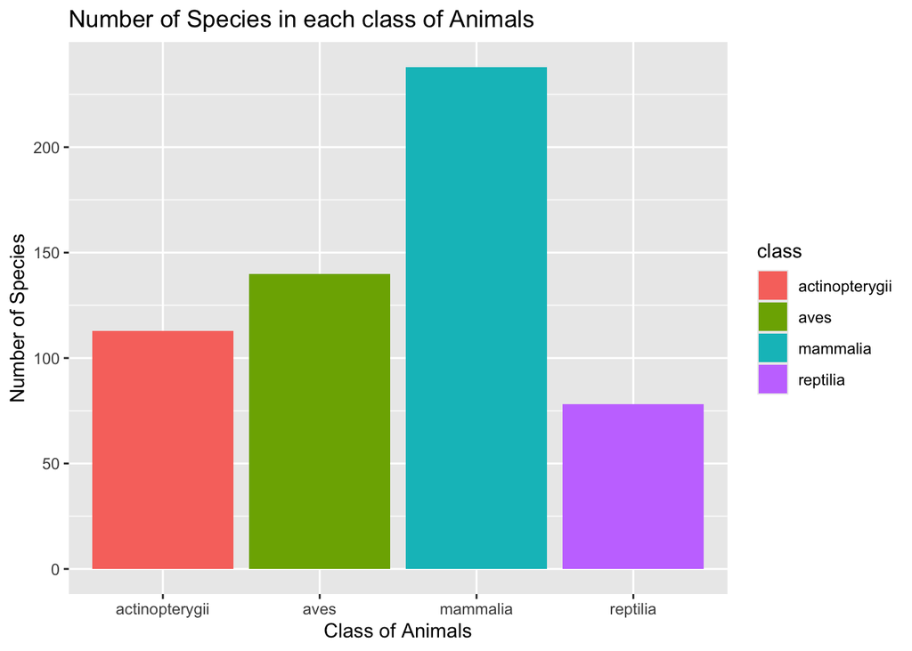

```r
ggplot(homerange, mapping = aes(x= class)) +
  geom_bar(mapping = aes(fill = class)) +
  labs (x= "Class of Animals", y= "Number of Species", title= "Number of Species in each class of Animals ")
```

**4. Are there more carnivores or herbivores represented in the data? Make a plot that shows the number in each trophic guild.**

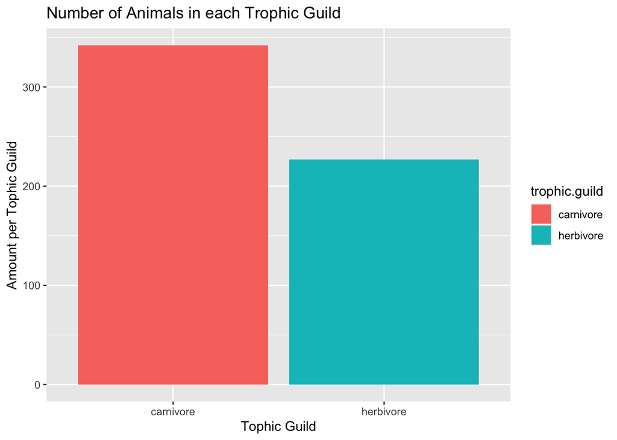

```r
ggplot (homerange, mapping= aes(x=trophic.guild)) +
  geom_bar (mapping = aes(fill= trophic.guild)) +
  labs( x= "Tophic Guild", y= "Amount per Tophic Guild", title= "Number of Animals in each Trophic Guild")
```

**5. Which herbivorous mammals have homeranges greater than 1,000,000 m²? Show only the common name, order, mean homerange size, and mean body mass. Arrange the data in descending order by homerange size and show only the top 10 species.**

```r
#homerange
#homerange %>%
  #select(common.name, class, order, mean.hra.m2, mean.mass.g) %>%
  #filter(class== "Mammalia", trophic.guild== "herbivore",
 #        mean.hra.m2 > 1e6)%>%
 # arrange(desc(mean.hra.m2, n=10))
```

[output not shown]